# IODS course project

### bprsL

A reminder of the variables in the data:

```r
str(bprsL)
```

```
## spec_tbl_df [360 x 4] (S3: spec_tbl_df/tbl_df/tbl/data.frame)
##  $ treatment: Factor w/ 2 levels "1","2": 1 1 1 1 1 1 1 1 1 1 ...
##  $ subject  : Factor w/ 20 levels "1","2","3","4",..: 1 2 3 4 5 6 7 8 9 10 ...
##  $ bprs     : num [1:360] 42 58 54 55 72 48 71 30 41 57 ...
##  $ week     : num [1:360] 0 0 0 0 0 0 0 0 0 0 ...
##  - attr(*, "spec")=
##   .. cols(
##   ..   treatment = col_double(),
##   ..   subject = col_double(),
##   ..   bprs = col_double(),
##   ..   week = col_double()
##   .. )
##  - attr(*, "problems")=<externalptr>
```

Okay, time to plot it:

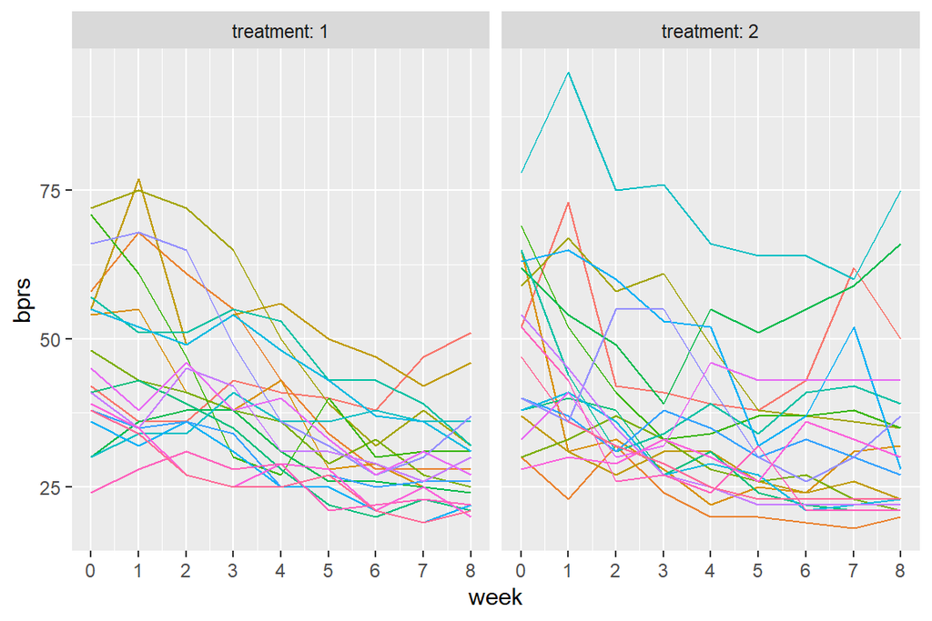

```r
bprsL %>% ggplot(
  aes(x = week, y = bprs, col = subject)) +
  geom_line() +
  facet_grid(. ~ treatment, labeller = label_both) +
  theme(legend.position = "none") +
  scale_x_continuous(breaks = seq(0, 8, 1))
```

Both treatment groups seem to have a linear reduction in bprs scores during the eight week treatment period. I wonder what a placebo group would look like.

Fitting a linear model:

```r
bprs_reg <- lm(bprs ~ week + treatment, bprsL)
bprs_reg %>% summary
```

```
##
## Call:
## lm(formula = bprs ~ week + treatment, data = bprsL)
##
## Residuals:
##     Min      1Q  Median      3Q     Max
## -22.454  -8.965  -3.196   7.002  50.244
##
## Coefficients:
##             Estimate Std. Error t value Pr(>|t|)
## (Intercept)  46.4539     1.3670  33.982   <2e-16 ***
## week         -2.2704     0.2524  -8.995   <2e-16 ***
## treatment2    0.5722     1.3034   0.439    0.661
## ---
## Signif. codes:  0 '***' 0.001 '**' 0.01 '*' 0.05 '.' 0.1 ' ' 1
##
## Residual standard error: 12.37 on 357 degrees of freedom
## Multiple R-squared:  0.1851, Adjusted R-squared:  0.1806
## F-statistic: 40.55 on 2 and 357 DF,  p-value: < 2.2e-16
```

Fitting a random intercept model:

```r
library(lme4)
bprs_ref <- lmer(bprs ~ week + treatment + (1 | subject), bprsL, REML = FALSE)
bprs_ref
```

```
## Linear mixed model fit by maximum likelihood  ['lmerMod']
## Formula: bprs ~ week + treatment + (1 | subject)
##    Data: bprsL
##       AIC       BIC    logLik  deviance  df.resid
##  2748.712  2768.143 -1369.356  2738.712       355
## Random effects:
##  Groups   Name        Std.Dev.
##  subject  (Intercept)  6.885
##  Residual             10.208
## Number of obs: 360, groups:  subject, 20
## Fixed Effects:
## (Intercept)         week   treatment2
##     46.4539      -2.2704       0.5722
```

```r
bprs_ref1 <- lmer(bprs ~ week + treatment + (week | subject), bprsL, REML = FALSE)
bprs_ref1 %>% summary
```

```
## Linear mixed model fit by maximum likelihood  ['lmerMod']
## Formula: bprs ~ week + treatment + (week | subject)
##    Data: bprsL
##
##      AIC      BIC   logLik deviance df.resid
##   2745.4   2772.6  -1365.7   2731.4      353
##
## Scaled residuals:
##     Min      1Q  Median      3Q     Max
## -2.8919 -0.6194 -0.0691  0.5531  3.7976
##
## Random effects:
##  Groups   Name        Variance Std.Dev. Corr
##  subject  (Intercept) 64.8222  8.0512
##           week         0.9609  0.9802   -0.51
##  Residual             97.4305  9.8707
## Number of obs: 360, groups:  subject, 20
##
## Fixed effects:
##             Estimate Std. Error t value
## (Intercept)  46.4539     2.1052  22.066
## week         -2.2704     0.2977  -7.626
## treatment2    0.5722     1.0405   0.550
##
## Correlation of Fixed Effects:
##            (Intr) week
## week       -0.582
## treatment2 -0.247  0.000
```

```r
anova(bprs_ref1, bprs_ref)
```

```
## Data: bprsL
## Models:
## bprs_ref: bprs ~ week + treatment + (1 | subject)
## bprs_ref1: bprs ~ week + treatment + (week | subject)
##           npar    AIC    BIC  logLik deviance  Chisq Df Pr(>Chisq)
## bprs_ref     5 2748.7 2768.1 -1369.4   2738.7
## bprs_ref1    7 2745.4 2772.6 -1365.7   2731.4 7.2721  2    0.02636 *
## ---
## Signif. codes:  0 '***' 0.001 '**' 0.01 '*' 0.05 '.' 0.1 ' ' 1
```

The standard error for treatment was lower in this linear mixed model compared to the linear regression model.

Trying *week + treatment* to *week * treatment*

```r
bprs_ref2 <- lmer(bprs ~ week * treatment + (week | subject), bprsL, REML = FALSE)
bprs_ref2 %>% summary
```

```
## Linear mixed model fit by maximum likelihood  ['lmerMod']
## Formula: bprs ~ week * treatment + (week | subject)
##    Data: bprsL
##
##      AIC      BIC   logLik deviance df.resid
##   2744.3   2775.4  -1364.1   2728.3      352
##
## Scaled residuals:
##     Min      1Q  Median      3Q     Max
## -3.0512 -0.6271 -0.0768  0.5288  3.9260
##
## Random effects:
##  Groups   Name        Variance Std.Dev. Corr
##  subject  (Intercept) 64.9964  8.0620
##           week         0.9687  0.9842   -0.51
##  Residual             96.4707  9.8220
## Number of obs: 360, groups:  subject, 20
##
## Fixed effects:
##                 Estimate Std. Error t value
## (Intercept)      47.8856     2.2521  21.262
## week             -2.6283     0.3589  -7.323
## treatment2       -2.2911     1.9090  -1.200
## week:treatment2   0.7158     0.4010   1.785
##
## Correlation of Fixed Effects:
##             (Intr) week   trtmn2
## week        -0.650
## treatment2  -0.424  0.469
## wek:trtmnt2  0.356 -0.559 -0.840
```

```r
anova(bprs_ref2, bprs_ref1)
```

```
## Data: bprsL
## Models:
## bprs_ref1: bprs ~ week + treatment + (week | subject)
## bprs_ref2: bprs ~ week * treatment + (week | subject)
##           npar    AIC    BIC  logLik deviance  Chisq Df Pr(>Chisq)
## bprs_ref1    7 2745.4 2772.6 -1365.7   2731.4
## bprs_ref2    8 2744.3 2775.4 -1364.1   2728.3 3.1712  1    0.07495 .
## ---
## Signif. codes:  0 '***' 0.001 '**' 0.01 '*' 0.05 '.' 0.1 ' ' 1
```

In this one the standard error was again larger. None of these model show evidence that there would be a difference in bprs score between the treatment groups.

Plotting the model with the smallest standard error:

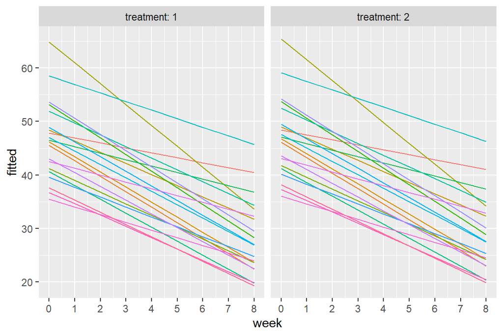

```r
bprsL$fitted <- fitted(bprs_ref1)

bprsL %>% ggplot(aes(x = week, y = fitted, group = subject)) +
  geom_line(aes(col = subject)) +
  facet_grid(. ~ treatment, labeller = label_both) +
  theme(legend.position = "none") +
  scale_x_continuous(breaks = seq(0, 8, 1))
```

As can be seen from these fitted plots, it’s hard to even see difference between them (I’m not lying there really is some if you look suuuper closely).

Finally, I’m plotting the original data and the fitted model next to each other:

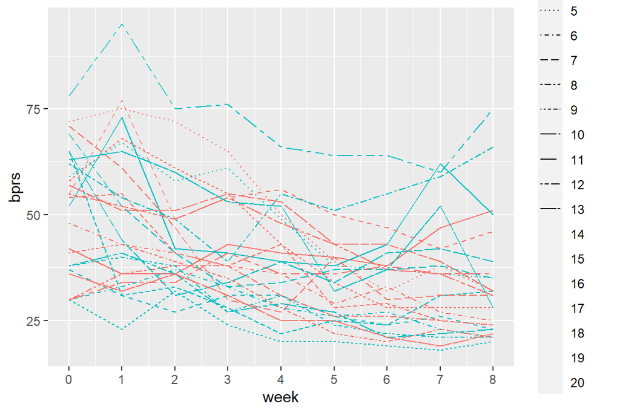

```r
p1 <- bprsL %>% ggplot(aes(x = week, y = bprs, color = treatment)) +
  geom_line(aes(linetype = subject)) +
  scale_x_continuous(breaks = seq(0, 8, 1))

p2 <- bprsL %>% ggplot(aes(x = week, y = fitted, color = treatment)) +
  geom_line(aes(linetype= subject)) +
  scale_x_continuous(breaks = seq(0, 8, 1))

par(mfrow = c(2, 1))
p1
```

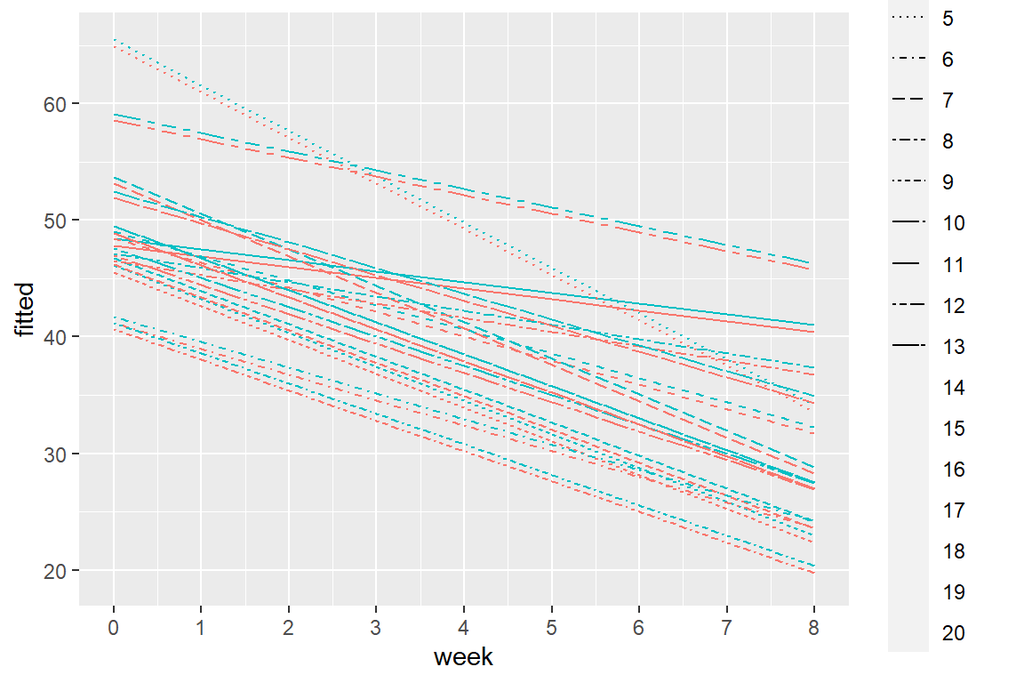

```r
p2
```

Here the treatments are separated by color and individuals by linetype. To be honest, I hate the linetypes but I couldn’t get the graph to work without it.